# Final Project

Luis Eduardo Acosta Aparicio

## Introduction

- How many rbi (Runs Batted In) can a player earn in a regular season?
- Which position in the line up could the player fit better in order to help the team to produce more runs? Which means more chance to win

I will be analyzing from my observational data set that I have collected over time from MLB regular seasons 2000-2016. In order to improve my data analysis I excluded pitchers, and players with less than 1000 at bat, also I chose the line up position with the most recurrent position in the past 16 seasons. The line up position is crucial for predicting. It is well known that players from 3 to 6 find more runners in score position than any other line up position.

The result will help scouts and team members to relocate players and predict rbi.

## Knowing the data set

| Variables | Description |
| --- | --- |
| player_id | `Player id` |
| player_name | `Player name` |
| at_bat | `Number of at bat` |
| rbi_average | `Total rbi divided by at bat` |
| hit_average | `Total hits divided by at bat` |
| line_average | `Total lines divided by at bat` |
| ground_average | `Total grounds divided by at bat` |
| fly_average | `Total flies divided by at bat` |
| strikeout_average | `Total strike outs divided by at bat` |
| lineup_position | `Most recurrent line up position` |

```r
path <- "C:\\Users\\leacosta.STU\\Documents\\project.csv"
data <- read.csv(path)
mlb_data <- data[ , c("rbi_average", "hit_average", "line_average", "ground_average", "lineup_position")]
```

```r
attach(mlb_data)
```

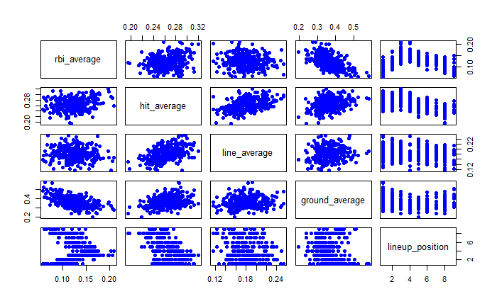

```r
pairs(mlb_data, pch=16, col="blue")
```

This pairs graph show us the correlation between variables. What I expected :

- line_average and hit_average to have an strong correletation, meaning the line drive is hardest to catch (more hits) , than grounds and flies in this order.
- lineup_position and rbi_average shows us positions 3, 4, 5 run batters in more than any other line up position.

Our model will use the following relation:

```r
mlb_model <- lm(rbi_average ~ hit_average + line_average + ground_average + format(lineup_position), data = mlb_data)
```

```r
summary(mlb_data)
```

```
  rbi_average      hit_average      line_average    ground_average   lineup_position
 Min.   :0.0584   Min.   :0.1947   Min.   :0.1161   Min.   :0.1943   Min.   :1.000
 1st Qu.:0.1022   1st Qu.:0.2488   1st Qu.:0.1643   1st Qu.:0.3208   1st Qu.:2.000
 Median :0.1219   Median :0.2621   Median :0.1809   Median :0.3575   Median :3.000
 Mean   :0.1231   Mean   :0.2635   Mean   :0.1814   Mean   :0.3639   Mean   :4.071
 3rd Qu.:0.1412   3rd Qu.:0.2797   3rd Qu.:0.1971   3rd Qu.:0.4056   3rd Qu.:6.000
 Max.   :0.2092   Max.   :0.3209   Max.   :0.2533   Max.   :0.5813   Max.   :9.000
```

```r
summary(mlb_model)
```

```
Call:
lm(formula = rbi_average ~ hit_average + line_average + ground_average +
    format(lineup_position), data = mlb_data)

Residuals:
      Min        1Q    Median        3Q       Max
-0.029749 -0.008996 -0.001147  0.007998  0.047274

Coefficients:
                          Estimate Std. Error t value Pr(>|t|)
(Intercept)               0.065343   0.012480   5.236 3.04e-07 ***
hit_average               0.660817   0.060822  10.865  < 2e-16 ***
line_average             -0.219223   0.034286  -6.394 5.94e-10 ***
ground_average           -0.261231   0.016442 -15.888  < 2e-16 ***
format(lineup_position)2  0.014618   0.002614   5.591 4.94e-08 ***
format(lineup_position)3  0.032195   0.003063  10.510  < 2e-16 ***
format(lineup_position)4  0.042626   0.003268  13.044  < 2e-16 ***
format(lineup_position)5  0.030952   0.002977  10.398  < 2e-16 ***
format(lineup_position)6  0.015821   0.003328   4.754 3.06e-06 ***
format(lineup_position)7  0.021401   0.004046   5.290 2.32e-07 ***
format(lineup_position)8  0.017106   0.003018   5.669 3.29e-08 ***
format(lineup_position)9  0.005194   0.004172   1.245    0.214
---
Signif. codes:  0 ‘***’ 0.001 ‘**’ 0.01 ‘*’ 0.05 ‘.’ 0.1 ‘ ’ 1

Residual standard error: 0.01373 on 310 degrees of freedom
Multiple R-squared:  0.7828,    Adjusted R-squared:  0.7751
F-statistic: 101.6 on 11 and 310 DF,  p-value: < 2.2e-16
```

The p-values for the selected variables are significants and Adjust R Square is 77%, meaning the model explain 77% the variability of the response around its means.

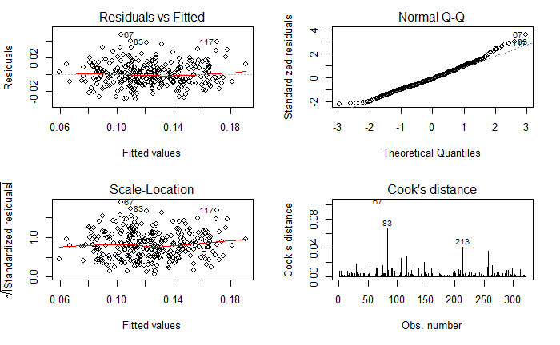

```r
par(mfrow=c(2,2))
plot(mlb_model, which = 1:4)
```

Residual vs Fitted

Observed values are not far away from 0, which means the model fitted well:

residual = observed y - model-predicted y, values should be around 0.

We have three residuals that are away from 0; 67, 83 and 117

Lets predict one of those data points (67), Wilson Ramos, 35 RBI in 2017:

```r
predict(mlb_model, list(line_average = 0.14903, ground_average = 0.4735, hit_average = 0.25961, lineup_position = 7)) * 280
```

```
       1
28.54172
```

The prediction for 2017 season is not that close.

Normal Q-Q

Observations lie well along the 45-degree line, so we can asume that normality holds here.

## Season (2017)

I picked 4 players with different positions in the line up and applied the model:

#### Yuliesky Gourriel

[figure not shown]

Y. Gourriel

At Bat : `529`

**RBI** : `75`

Most recurrent line up position : `7`

| Variables | Values | Average |
| --- | --- | --- |
| Hits | `158` | `0.29867` |
| Lines Drive | `88` | `0.16635` |
| Grounds | `218` | `0.41209` |

```r
predict(mlb_model, list(line_average = 0.16635, ground_average = 0.41209, hit_average = 0.29867, lineup_position = 7)) * 529
```

```
       1
74.05549
```

#### Jose Abreu

[figure not shown]

J. Abreu

At Bat : `621`

**RBI** : `102`

Most recurrent line up position : `5`

| Variables | Values | Average |
| --- | --- | --- |
| Hits | `189` | `0.30434` |
| Lines Drive | `92` | `0.14814` |
| Grounds | `229` | `0.36876` |

```r
predict(mlb_model, list(line_average = 0.14814, ground_average = 0.36876, hit_average = 0.30434, lineup_position = 5)) * 621
```

```
       1
104.7012
```

#### Jose Altuve

[figure not shown]

J. Altuve

At Bat : `590`

**RBI** : `81`

Most recurrent line up position : `1`

[output not shown]

```r
predict(mlb_model, list(line_average = 0.17288, ground_average = 0.4, hit_average = 0.32033, lineup_position = 1)) * 590
```

```
      1
79.4323
```

#### Evan Longoria

[figure not shown]

E. Longoria

At Bat : `613`

**RBI** : `86`

Most recurrent line up position : `3`

[output not shown]

```r
predict(mlb_model, list(line_average = 0.16630, ground_average = 0.36541, hit_average = 0.26101, lineup_position = 3)) * 613
```

```
       1
84.65801
```

# Conclusion

The predictions for players selected were close to their RBI in 2017. The model works as expected. The baseball game has a lot of stats that can influence our results. I learned we cannot exclude variables we know are important like lineup_position in this case which improved my predictions notably.

I will keep working on this model to improve it to help coaches to find the perfect fit in their line up.

# References

Fan Graph - https://www.fangraphs.com

ESPN - http://www.espn.com/

Retrosheet - http://www.retrosheet.org/

Baseball Reference - https://www.baseball-reference.com/